# Laboratorio Razonamiento - Diplomado IA Educacion Continua UC

```python
!pip install torch==2.11.0 torchvision==0.26.0 torchaudio==2.11.0 --index-url https://download.pytorch.org/whl/cu128

!pip install accelerate==1.14.0 \
    einops==0.8.2 \
    evaluate==0.4.6 \
    gdown==5.2.2 \
    liger-kernel==0.8.0 \
    ml_dtypes==0.5.4 \
    nltk==3.9.1 \
    numpy==2.0.2 \
    packaging==26.2 \
    pandas==2.2.2 \
    peft==0.19.1 \
    torchao==0.17.0 \
    torchdata==0.11.0 \
    torchsummary==1.5.1 \
    torchtune==0.6.1 \
    tqdm==4.67.3 \
    transformers==5.12.1 \
    trl==1.7.1 \
    rapidfuzz==3.14.5 \
    dspy==3.2.1 \
    bitsandbytes==0.49.2
```

[output not shown]

```python
!gdown 1wGcNYF4tqXb7j20IWJibzdTO0dyfeUyj
!gdown 1YlHIj-8eVCdDglIrPju4uw1OGwBwacNq
```

```
Downloading...
From: https://drive.google.com/uc?id=1wGcNYF4tqXb7j20IWJibzdTO0dyfeUyj
To: /content/conversations_qw_3_6p_2.zip
100% 5.04M/5.04M [00:00<00:00, 244MB/s]
Downloading...
From: https://drive.google.com/uc?id=1YlHIj-8eVCdDglIrPju4uw1OGwBwacNq
To: /content/dict_A_to_I.txt
100% 8.98M/8.98M [00:00<00:00, 184MB/s]
```

```python
!unzip conversations_qw_3_6p_2.zip
```

[output not shown]

[output cut: 1108 more lines]

[output not shown]

# Uso de herramientas

Vamos a darle a un modelo la capacidad de usar un diccionario del idioma Lakota, y vamos a pedirle que lo utilice para realizar traducciones desde el ingles.

[figure not shown]

```python
import json
import re
import threading
import unicodedata

import torch
from transformers import AutoModelForCausalLM, AutoTokenizer, BitsAndBytesConfig, TextIteratorStreamer
from rapidfuzz import fuzz


# A continuación se encuentra nuestro diccionaro, esta es una clase que recibe
# texto y retorna las entradas del diccionario con mayor correspondencia
# con el input de la busqueda

class LakotaDictionaryTool:
    def __init__(self, raw_data):
        self.entries = self._parse_data(raw_data)

    def _parse_data(self, data):
        entries = []
        for raw_entry in re.split(r"(?=\\lx )", data):
            if not raw_entry.strip():
                continue
            entry_obj = {"lexeme": "", "senses": []}
            current_sense = {"definition": "", "examples": []}
            for line in raw_entry.strip().split("\n"):
                m = re.match(r"^\\(\w+)\s+(.*)", line.strip())
                if not m:
                    continue
                marker, content = m.groups()
                if marker == "lx":
                    entry_obj["lexeme"] = content
                elif marker == "ps":
                    entry_obj["part_of_speech"] = content
                elif marker == "sn":
                    if current_sense["definition"] or current_sense["examples"]:
                        entry_obj["senses"].append(current_sense)
                    current_sense = {"definition": "", "examples": [], "usage": "", "sense_number": content}
                elif marker == "de":
                    current_sense["definition"] = content
                elif marker == "ue":
                    current_sense["usage"] = content
                elif marker == "xv":
                    current_sense["examples"].append({"lakota": content, "english": ""})
                elif marker == "xe" and current_sense["examples"]:
                    current_sense["examples"][-1]["english"] = content
            if current_sense["definition"] or current_sense["examples"]:
                entry_obj["senses"].append(current_sense)
            if entry_obj["lexeme"]:
                entries.append(entry_obj)
        return entries

    def _norm(self, text):
        if not text:
            return ""
        text = text.replace("ŋ", "n").replace("Ŋ", "N")
        text = unicodedata.normalize("NFD", text)
        return "".join(c for c in text if unicodedata.category(c) != "Mn").lower().strip()

    def _fuzzy(self, query, text, nq=None, nt=None):
        if not text:
            return 0.0
        nq = nq or self._norm(query)
        nt = nt or self._norm(text)
        if nq == nt:
            return 1.0
        return max((fuzz.ratio(nq, w) / 100.0 for w in re.findall(r"\w+", nt)), default=0.0)

    def _exact_word(self, q, t):
        return bool(t and q and re.search(r"\b" + re.escape(q) + r"\b", t))

    def search(self, query, limit=5, threshold=0.65):
        results = []
        nq = self._norm(query)
        for entry in self.entries:
            best = 0.0
            lx = entry.get("lexeme", "")
            nlx = self._norm(lx)
            best = max(best, 3.0 if nlx == nq else self._fuzzy(query, lx, nq, nlx) * 1.5)
            for sense in entry["senses"]:
                d = sense.get("definition", "")
                nd = self._norm(d)
                if nd == nq:
                    best = max(best, 2.5)
                elif self._exact_word(nq, nd):
                    best = max(best, 2.1)
                else:
                    penalty = 0.9 if len(nd) > len(nq) * 3 else 1.0
                    best = max(best, self._fuzzy(query, d, nq, nd) * penalty)
                for ex in sense.get("examples", []):
                    for field, exact_s, mult in [("lakota", 2.8, 0.8), ("english", 2.3, 0.8)]:
                        raw = ex.get(field, "")
                        nr = self._norm(raw)
                        if nr == nq:
                            best = max(best, exact_s)
                        elif self._exact_word(nq, nr):
                            best = max(best, exact_s - 0.6)
                        else:
                            best = max(best, self._fuzzy(query, raw, nq, nr) * mult)
            if best >= threshold:
                results.append((best, entry))
        results.sort(key=lambda x: -x[0])
        return [r[1] for r in results[:limit]]

    def format_results(self, results):
        if not results:
            return "No results found."
        lines = []
        for entry in results:
            line = f"**{entry.get('lexeme', '?')}** ({entry.get('part_of_speech', 'pk')})"
            senses = entry.get("senses", [])
            for i, s in enumerate(senses, 1):
                prefix = f" {i}. " if len(senses) > 1 else " "
                line += f"{prefix}{s.get('definition', '').strip()}"
                if s.get("usage", "").strip():
                    line += f" [Note: {s['usage'].strip()}]"
                if s.get("examples"):
                    exs = "; ".join(f"{e['lakota']} -> {e['english']}" for e in s["examples"])
                    line += f" | Example: {exs}"
            lines.append(line)
        return "\n".join(lines)


# Definimos las herramientas existentes,
# el formato a utilizar depende del modelo a usar
TOOLS = [
    {
        "type": "function",
        "function": {
            "name": "search_dictionary",
            "description": "Performs a fuzzy text search on the Lakota dictionary.",
            "parameters": {
                "type": "object",
                "properties": {
                    "query": {"type": "string", "description": "The word or definition to search for."},
                    "limit": {"type": "integer", "description": "Max results (default 4).", "default": 4},
                },
                "required": ["query"],
            },
        },
    }
]
```

```python
import json
import re
import threading
import unicodedata

import torch
from transformers import AutoModelForCausalLM, AutoTokenizer, BitsAndBytesConfig, TextIteratorStreamer
from rapidfuzz import fuzz


# Esta es la instruccion que le entregaremos al modelo,
# es utilizada para variar su comportamiento

SYSTEM_PROMPT_TEMPLATE = """# Tools

You have access to the following functions:

<tools>
{tools_block}
</tools>

<tool_call>
<function=example_function_name>
<parameter=example_parameter_1>
value_1
</parameter>
</function>
</tool_call>

Reminder:
- Function calls MUST follow the specified format: an inner <function=...></function> block must be nested within <tool_call></tool_call> XML tags.
- Required parameters MUST be specified.

You are a careful English-to-Lakota translator.

Rules:
1. For every translation request, use the search_dictionary function at least once before giving the final translation.
2. You may call the dictionary multiple times to verify roots, alternate spellings, affixes, or meanings.
3. Prefer conservative translations grounded in the dictionary results.
4. You have a maximum of {max_turns} turns available, there is no limit to the number of tool calls in total or per turn, but find the necessary words efficiently and provide the final answer before exceeding this limit.
5. In the final answer, output:
   - Lakota: <final translation>
   - Notes: <brief explanation of word choices and uncertainty if any>
6. Do not invent dictionary evidence that was not returned by the tool.
7. You do not have to rely entirely on exact definitions, the tool results can include examples of translations from which you can infer the meaning of the word in the context of the sentence.
8. It is recommended to perform multiple tool calls in parallel.
9. Start every turn by repeating the number of turns you have in which you are allowed to perform further tool calls, if you do not have any tool-calling turns left then proceed to answer the translation with the information you currently have.
10. Do not make up any Lakota words of definition on your own, your internal knowledge cannot be trusted and rely entirely on the results of the dictionary tool call.
"""

TOOL_CALL_RE = re.compile(r"<tool_call>\s*<function=([^\n>]+)>\s*(.*?)</function>\s*</tool_call>", re.DOTALL)
PARAM_RE = re.compile(r"<parameter=([^>\n]+)>\s*(.*?)\s*</parameter>", re.DOTALL)


def parse_tool_calls(text):
    calls = []
    for fn_name, fn_body in TOOL_CALL_RE.findall(text or ""):
        args = {}
        for pname, pval in PARAM_RE.findall(fn_body):
            try:
                args[pname.strip()] = json.loads(pval.strip())
            except Exception:
                args[pname.strip()] = pval.strip()
        calls.append({"name": fn_name.strip(), "arguments": args})
    return calls


def execute_tool_call(name, args, dictionary_tool):
    if name != "search_dictionary":
        return f"ERROR: Unknown tool '{name}'."
    query = args.get("query")
    if not isinstance(query, str) or not query.strip():
        return "ERROR: search_dictionary requires a non-empty string 'query'."
    limit = int(args.get("limit", 4))
    return dictionary_tool.format_results(dictionary_tool.search(query=query, limit=limit))


def load_model(model_name="Qwen/Qwen3-4B", lora_path=None, load_in_4bit=False, flash_attn=False):
    tokenizer = AutoTokenizer.from_pretrained(model_name, trust_remote_code=True, padding_side="left")
    if tokenizer.pad_token is None:
        tokenizer.pad_token = tokenizer.eos_token

    bnb_config = None
    if load_in_4bit:
        bnb_config = BitsAndBytesConfig(
            load_in_4bit=True, bnb_4bit_quant_type="nf4",
            bnb_4bit_compute_dtype=torch.bfloat16, bnb_4bit_use_double_quant=True,
        )

    model = AutoModelForCausalLM.from_pretrained(
        model_name, trust_remote_code=True, quantization_config=bnb_config,
        torch_dtype=torch.bfloat16 if not load_in_4bit else None,
        device_map="auto",
        attn_implementation="flash_attention_2" if flash_attn else None,
    )

    if lora_path:
        from peft import PeftModel
        model = PeftModel.from_pretrained(model, lora_path).merge_and_unload()

    model.eval()
    return model, tokenizer

def _build_eos_token_ids(tokenizer):
    eos_token_ids = []
    if tokenizer.eos_token_id is not None:
        eos_token_ids.append(tokenizer.eos_token_id)

    vocab = tokenizer.get_vocab()
    for token in ["<|im_end|>", "<|endoftext|>"]:
        token_id = vocab.get(token)
        if token_id is not None and token_id not in eos_token_ids:
            eos_token_ids.append(token_id)

    return eos_token_ids


def _clean_generated_text(text: str) -> str:
    cutoff_markers = [
        "<tool_response>",
        "user\n<tool_response>",
        "user\n",
    ]
    for marker in cutoff_markers:
        if marker in text:
            text = text.split(marker)[0]
    return text.strip()


def _render_chat(tokenizer, messages, add_generation_prompt: bool) -> str:
    return tokenizer.apply_chat_template(
        messages,
        tokenize=False,
        add_generation_prompt=add_generation_prompt,
        enable_thinking=True,
    )


def _build_incremental_input_ids(tokenizer, cached_messages, current_messages, device):
    full_text = _render_chat(tokenizer, current_messages, add_generation_prompt=True)

    if not cached_messages:
        input_ids = tokenizer(
            full_text,
            add_special_tokens=False,
            return_tensors="pt",
        ).input_ids.to(device)
        return input_ids, False

    cached_text = _render_chat(tokenizer, cached_messages, add_generation_prompt=False)

    if full_text.startswith(cached_text):
        delta_text = full_text[len(cached_text):]
        input_ids = tokenizer(
            delta_text,
            add_special_tokens=False,
            return_tensors="pt",
        ).input_ids.to(device)
        return input_ids, False

    input_ids = tokenizer(
        full_text,
        add_special_tokens=False,
        return_tensors="pt",
    ).input_ids.to(device)
    return input_ids, True


def generate(
    model,
    tokenizer,
    input_ids,
    past_key_values=None, # Parametro importante, cache
    max_new_tokens=2048,
    temperature=0.6,
    stream=False,
):
    eos_token_id = _build_eos_token_ids(tokenizer)

    gen_kwargs = dict(
        input_ids=input_ids,
        past_key_values=past_key_values,
        max_new_tokens=max_new_tokens,
        pad_token_id=tokenizer.pad_token_id,
        eos_token_id=eos_token_id,
        # En general los modelos tienen parametros de muestreo recomendados
        # con los que generan mejores respuestas (mayor puntaje en algun benchmark)
        # https://huggingface.co/Qwen/Qwen3.5-2B#best-practices
        temperature=temperature,
        do_sample=temperature>0,
        top_p=0.95,
        top_k=20,
        min_p=0.0,
        repetition_penalty=1.0,
        return_dict_in_generate=True,
        use_cache=True,
        stop_strings=["<tool_response>", "<|im_start|>", "user\n<tool_response>"],
        tokenizer=tokenizer,
    )

    if stream:
        streamer = TextIteratorStreamer(
            tokenizer,
            skip_prompt=True,
            skip_special_tokens=False,
        )
        gen_kwargs["streamer"] = streamer

        output_container = {}

        def target():
            with torch.no_grad():
                output_container["result"] = model.generate(**gen_kwargs)

        thread = threading.Thread(target=target)
        thread.start()

        for chunk in streamer:
            print(chunk, end="", flush=True)
        print()

        thread.join()
        outputs = output_container["result"]
    else:
        with torch.no_grad():
            outputs = model.generate(**gen_kwargs)

    # Decode only newly generated tokens relative to THIS call's input_ids
    gen_tokens = outputs.sequences[0, input_ids.shape[1]:]
    generated_text = tokenizer.decode(gen_tokens, skip_special_tokens=True)
    generated_text = _clean_generated_text(generated_text)

    new_past_key_values = getattr(outputs, "past_key_values", None)
    return generated_text, new_past_key_values


def translate(
    english_text,
    dictionary_tool,
    model,
    tokenizer,
    max_turns=5,
    max_new_tokens=2048,
    temperature=0.6,
    stream=False,
    output_file=None,
):
    tools_block = "\n".join(json.dumps(t, ensure_ascii=False) for t in TOOLS)
    system_prompt = SYSTEM_PROMPT_TEMPLATE.format(
        tools_block=tools_block,
        max_turns=max_turns,
    )

    messages = [
        {"role": "system", "content": system_prompt},
        {
            "role": "user",
            "content": f"Translate the following English text into Lakota.\n\nEnglish: {english_text}",
        },
    ]

    # Messages already represented by the current KV cache.
    cached_messages = []
    past_key_values = None
    assistant_text = ""

    for step in range(max_turns + 2):
        print(f"\n--- Turn {step + 1} ---")

        current_input_ids, reset_cache = _build_incremental_input_ids(
            tokenizer=tokenizer,
            cached_messages=cached_messages,
            current_messages=messages,
            device=model.device,
        )

        if reset_cache:
            past_key_values = None

        assistant_text, past_key_values = generate(
            model=model,
            tokenizer=tokenizer,
            input_ids=current_input_ids,
            past_key_values=past_key_values,
            max_new_tokens=max_new_tokens,
            temperature=temperature,
            stream=stream,
        )

        if not stream:
            print(f"Assistant:\n{assistant_text}")

        messages.append({"role": "assistant", "content": assistant_text})

        # Cache now represents everything up through this assistant turn.
        cached_messages = list(messages)

        tool_calls = parse_tool_calls(assistant_text)

        if not tool_calls:
            print("\nDone (no tool calls).")
            break

        if step >= max_turns:
            print("\nMax turns exhausted. The model will not be allowed further tool calls.")
            reminder = (
                "You have 0 turns left for dictionary searches."
                "You MUST provide the final Lakota translation now in your next response."
            )
            messages.append({"role": "user", "content": reminder})
            continue

        tool_response_blocks = []
        for tc in tool_calls:
            print(f"  Tool: {tc['name']}({tc['arguments']})")
            output = execute_tool_call(tc["name"], tc["arguments"], dictionary_tool)
            print(f"  Result: {output}")
            tool_response_blocks.append(f"<tool_response>\n{output}\n</tool_response>")

        steps_left = max_turns - step - 1
        if steps_left > 0:
            reminder = (
                f"\n\n<system_reminder>You have {steps_left} turn(s) left. "
                "Please provide the final translation if you have enough information."
                "</system_reminder>"
            )
        else:
            reminder = (
                "\n\n<system_reminder>You have 0 turns left for dictionary searches. "
                "You MUST provide the final Lakota translation now in your next response "
                "without using any more tools.</system_reminder>"
            )

        tool_content = "\n".join(tool_response_blocks) + reminder
        messages.append({"role": "user", "content": tool_content})

    if output_file:
        with open(output_file, "w", encoding="utf-8") as f:
            for msg in messages:
                f.write(json.dumps(msg, ensure_ascii=False) + "\n")
        print(f"Saved to {output_file}")

    return assistant_text.strip(), messages
```

```python
from transformers import AutoModelForCausalLM, AutoTokenizer
from peft import PeftModel
import torch

# La architectura de modelos Qwen de Alibaba es muy utilizada,
# tiene uno de los mejores desempenos en relacion a su tamano
# y tiene gran variedad en tamanos de modelos, utiles en distintas
# capacidades de hardware, los mas pequenos son de 0.8, 2 y 4 billones de
# parametros
base_model_id = "Qwen/Qwen3.5-4B"

base_model = AutoModelForCausalLM.from_pretrained(
    base_model_id,
    torch_dtype=torch.float16,
    device_map="cuda"
)
tokenizer = AutoTokenizer.from_pretrained(base_model_id)
```

[output not shown]

```
[transformers] `torch_dtype` is deprecated! Use `dtype` instead!
```

```
[transformers] The fast path is not available because one of the required library is not installed. Falling back to torch implementation. To install follow https://github.com/fla-org/flash-linear-attention#installation and https://github.com/Dao-AILab/causal-conv1d
```

```python
raw_data = open("dict_A_to_I.txt", "r", encoding="utf-8").read()
dictionary_tool = LakotaDictionaryTool(raw_data)
```

```python
translate("The quick brown fox jumps over the lazy dog", dictionary_tool, base_model, tokenizer, stream=True, max_turns=2)
```

```
--- Turn 1 ---
```

```
[transformers] The attention mask is not set and cannot be inferred from input because pad token is same as eos token. As a consequence, you may observe unexpected behavior. Please pass your input's `attention_mask` to obtain reliable results.
```

```
The user wants me to translate the pangram "The quick brown fox jumps over the lazy dog" into Lakota. I need to use the search_dictionary tool to find the appropriate Lakota translations for each word.

Let me start by searching for the key words:
- The
- quick
- brown
- fox
- jumps
- over
- lazy
- dog

I'll need to search for these terms to find their Lakota equivalents. Let me make multiple tool calls in parallel to search for these words efficiently.

Actually, looking at the function, it's a fuzzy text search on the Lakota dictionary. This might not work perfectly for searching for English words to find their Lakota translations. Let me try searching for some of the key words to see what comes up.

Let me start with searching for common words and see what I get.
</think>

<tool_call>
<function=search_dictionary>
<parameter=query>
quick
</parameter>
<parameter=limit>
4
</parameter>
</function>
</tool_call>
<tool_call>
<function=search_dictionary>
<parameter=query>
brown
</parameter>
<parameter=limit>
4
</parameter>
</function>
</tool_call>
<tool_call>
```

[output cut: 218 more lines]

```
Lakota: šúŋǧíla kȟo ǧí napsíčA ačhákšiŋ šúŋka kapíŋ

Notes:
- "quick" = kȟo (root)
- "brown" = ǧí (to be brown)
- "fox" = šuŋǧíla (red fox)
- "jumps" = napsíčA (it jumps, hops, leaps)
- "over" = ačhákšiŋ (to step over something/someone) - used here for "over" in the context of jumping
- "lazy" = kapíŋ (to be reluctant to do, tired, unwilling) - used for lazy/reluctant quality
- "dog" = šúŋka (dog)
- "The" is not translated as a separate word in Lakota; definite articles are often implied through context

The word order follows Lakota SOV (Subject-Object-Verb) structure, with adjectives placed before nouns. The verb "napsíčA" is in the third person singular form (it jumps).<|im_end|>

Done (no tool calls).
```

[output not shown]

# Parameter Efficient Fine-Tuning (PEFT)

El tipo de PEFT que vamos a utilizar se llama Low-Rank Adaptation (LoRA). Este método añade 2 matrices de menor tamaño como parámetros entrenables que funcionan como adaptadores, usualmente sobre cada uno de los pesos original del modelo pero podría ser sobre solo los pesos de la atención por ejemplo. Algunas de las ventajas que LoRA puede presentar es menor interferencia (*catastrophic forgetting*) sobre la información en los pesos y menor uso de memoria.

El menor uso de memoria es debido a que no necesitamos almacenar todos los pesos en *float32* (4 bytes), solo las nuevas matrices de adaptación, y los parámetros actuales del modelo pueden ser almacenados con 2 bytes (*float16* o *bfloat16*).

Además, ya que solo entrenamos estas nuevas matrices, el optimizador matiene estados solamente para estos pesos (por ejemplo *Adam* mantiene información sobre la varianza y momentum para cada peso, y como usualmente también son almacenados en *float32*, representan 8 bytes adicionales por cada peso entrenable).

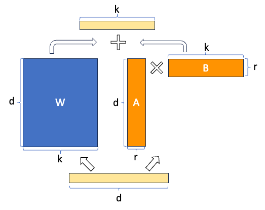

```python
import argparse
import json
import os
import re
from pathlib import Path
from typing import Dict, List

import torch
from datasets import Dataset
from peft import LoraConfig, get_peft_model, prepare_model_for_kbit_training
from transformers import (
    AutoModelForCausalLM,
    AutoTokenizer,
    BitsAndBytesConfig,
    TrainingArguments,
)
from trl import SFTTrainer


def load_conversations(conversation_dirs: List[str]) -> List[List[Dict]]:
    """Load all .jsonl conversation files, each as a list of messages."""
    conversations = []
    for d in conversation_dirs:
        p = Path(d)
        if not p.exists():
            print(f"Warning: {d} does not exist, skipping.")
            continue
        for f in sorted(p.glob("*.jsonl")):
            if "FAILED" in f.name:
                continue
            msgs = []
            with open(f, encoding="utf-8") as fh:
                for line in fh:
                    line = line.strip()
                    if line:
                        msgs.append(json.loads(line))
            if msgs:
                conversations.append(msgs)
    return conversations


def format_conversation_for_training(
    messages: List[Dict],
    include_reasoning: bool = True,
) -> List[Dict[str, str]]:
    formatted: List[Dict[str, str]] = []

    for msg in messages:
        role = msg["role"]
        content = msg.get("content", "") or ""
        reasoning = msg.get("reasoning", "") or ""

        if role == "system":
            clean = re.sub(
                r"You have a maximum of \d+ turns.*?this limit\.",
                "Use the dictionary tool as many times as needed to produce an accurate translation.",
                content,
                flags=re.DOTALL,
            )
            formatted.append({"role": "system", "content": clean})

        elif role == "user":
            formatted.append({"role": "user", "content": content})

        elif role == "assistant":
            if include_reasoning and reasoning.strip():
                combined = f"<think>\n{reasoning.strip()}\n</think>\n{content}"
            else:
                combined = content
            formatted.append({"role": "assistant", "content": combined})

    return formatted

def build_dataset(
    conversation_dirs: List[str],
    tokenizer,
    include_reasoning: bool = True,
    max_seq_length: int = 4096 * 5,
) -> Dataset:
    raw_convos = load_conversations(conversation_dirs)
    print(f"Loaded {len(raw_convos)} conversations")

    records = []
    skipped = 0
    for convo in raw_convos:
        formatted = format_conversation_for_training(convo, include_reasoning)
        text = tokenizer.apply_chat_template(
            formatted, tokenize=False, add_generation_prompt=False
        )
        token_count = len(tokenizer.encode(text, add_special_tokens=False))
        if token_count > max_seq_length:
            skipped += 1
            continue
        records.append({"text": text})

    print(f"Kept {len(records)} samples, skipped {skipped} (over {max_seq_length} tokens)")
    return Dataset.from_list(records)

def train(
    model_name: str,
    conversation_dirs: List[str],
    output_dir: str,
    include_reasoning: bool = True,
    max_seq_length: int = 20480,
    val_split: float = 0.1,
    load_in_4bit: bool = True,
    load_in_8bit: bool = True,
    flash_attn: bool = False,
    lora_r: int = 16,
    lora_alpha: int = 32,
    lora_dropout: float = 0.05,
    epochs: int = 3,
    batch_size: int = 2,
    gradient_accumulation_steps: int = 8,
    lr: float = 2e-5,
    gradient_checkpointing: bool = True
):
    tokenizer = AutoTokenizer.from_pretrained(
        model_name,
        trust_remote_code=True,
        padding_side="right",
    )
    if tokenizer.pad_token is None:
        tokenizer.pad_token = tokenizer.eos_token

    dataset = build_dataset(
        conversation_dirs,
        tokenizer,
        include_reasoning=include_reasoning,
        max_seq_length=max_seq_length,
    )

    if val_split > 0 and len(dataset) > 10:
        split = dataset.train_test_split(test_size=val_split, seed=42)
        train_dataset = split["train"]
        eval_dataset = split["test"]
    else:
        train_dataset = dataset
        eval_dataset = None

    bnb_config = None
    if load_in_4bit:
        bnb_config = BitsAndBytesConfig(
            load_in_4bit=True,
            bnb_4bit_quant_type="nf4",
            bnb_4bit_compute_dtype=torch.bfloat16,
            bnb_4bit_use_double_quant=True,
        )

    if load_in_8bit:
        bnb_config = BitsAndBytesConfig(
            load_in_8bit=True,
        )

    model = AutoModelForCausalLM.from_pretrained(
        model_name,
        trust_remote_code=True,
        quantization_config=bnb_config,
        torch_dtype=torch.bfloat16 if not load_in_4bit else None,
        device_map="auto",
        attn_implementation="sdpa" if flash_attn else None,
    )

    if load_in_4bit or load_in_8bit:
        model = prepare_model_for_kbit_training(model)

    lora_config = LoraConfig(
        r=lora_r,
        lora_alpha=lora_alpha,
        lora_dropout=lora_dropout,
        bias="none",
        task_type="CAUSAL_LM",
        target_modules="all-linear",
    )
    model = get_peft_model(model, lora_config)
    model.print_trainable_parameters()

    training_args = TrainingArguments(
        output_dir=output_dir,
        num_train_epochs=epochs,
        per_device_train_batch_size=batch_size,
        per_device_eval_batch_size=1,
        gradient_accumulation_steps=gradient_accumulation_steps,
        learning_rate=lr,
        lr_scheduler_type="cosine",
        warmup_ratio=0.1,
        weight_decay=0.01,
        bf16=True,
        logging_steps=5,
        save_strategy="epoch",
        eval_strategy="steps" if eval_dataset else "no",
        eval_steps=10,
        save_total_limit=5,
        report_to="none",
        gradient_checkpointing=gradient_checkpointing,
        gradient_checkpointing_kwargs={"use_reentrant": False} if gradient_checkpointing else None,
        optim="adamw_torch_fused" if torch.cuda.is_available() else "adamw_torch",
        max_grad_norm=1.0,
        seed=42,
        use_liger_kernel=True,
    )

    trainer = SFTTrainer(
        model=model,
        args=training_args,
        train_dataset=train_dataset,
        eval_dataset=eval_dataset,
        processing_class=tokenizer,
    )

    train_output = trainer.train()
    trainer.save_model(os.path.join(output_dir, "final"))
    tokenizer.save_pretrained(os.path.join(output_dir, "final"))
    print(f"\nModel saved to {output_dir}/final")

    return trainer, train_output
```

```python
trainer, model_output = train(
    model_name="Qwen/Qwen3.5-2B",
    conversation_dirs=[
        "./conversations_qw_3_6p_2",
    ],
    output_dir="output",
    include_reasoning=True,
    load_in_4bit=False,
    load_in_8bit=False,
    flash_attn=True,
    lora_r=128,
    gradient_checkpointing=False,
    batch_size=1,
    gradient_accumulation_steps=16,
    epochs=1,
)
```

```
Loaded 580 conversations
Kept 580 samples, skipped 0 (over 20480 tokens)
```

```
[transformers] warmup_ratio is deprecated and will be removed in v5.2. Use `warmup_steps` instead.
[transformers] warmup_ratio is deprecated and will be removed in v5.2. Use `warmup_steps` instead.
```

```
trainable params: 134,553,600 || all params: 2,016,378,688 || trainable%: 6.6730
```

```
[transformers] The tokenizer has new PAD/BOS/EOS tokens that differ from the model config and generation config. The model config and generation config were aligned accordingly, being updated with the tokenizer's values. Updated tokens: {'eos_token_id': 248046, 'pad_token_id': 248044}.
[transformers] `use_return_dict` is deprecated! Use `return_dict` instead!
```

[33/33 15:31, Epoch 1/1]

| Step | Training Loss | Validation Loss | Num Tokens | Mean Token Accuracy |
| --- | --- | --- | --- | --- |
| 10 | 2.574812 | 2.354506 | 163840.000000 | 0.574729 |
| 20 | 2.053653 | 2.026958 | 327530.000000 | 0.613291 |
| 30 | 1.931625 | 1.946516 | 491370.000000 | 0.620504 |
| 33 | 1.931625 | 1.945518 | 534378.000000 | 0.622341 |

```
Model saved to output/final
```

```python
translate("The quick brown fox jumps over the lazy dog", dictionary_tool, trainer.model, tokenizer, stream=True, max_turns=2)
```

```
--- Turn 1 ---
The user wants me to translate "The quick brown fox jumps over the lazy dog" into Lakota. I need to search the dictionary for this phrase to find appropriate Lakota equivalents.

Let me search for key words in the phrase:
1. "fox" - to find how to say fox in Lakota
2. "jump" - to find how to say jump in Lakota
3. "lazy" - to find how to say lazy in Lakota
4. "dog" - to find how to say dog in Lakota

I'll search for these words to get accurate translations.
</think>

<tool_call>
<function=search_dictionary>
<parameter=query>
fox
</parameter>
<parameter=limit>
3
</parameter>
</function>
</tool_call>
<tool_call>
<function=search_dictionary>
<parameter=query>
lazy
</parameter>
<parameter=limit>
3
</parameter>
</function>
</tool_call>
<tool_call>
<function=search_dictionary>
<parameter=query>
jump
</parameter>
<parameter=limit>
3
</parameter>
```

[output cut: 150 more lines]

```
Actually, I need to reconsider the translation. The sentence is "The quick brown fox jumps over the lazy dog". In Lakota, this might be:

- The quick brown fox: šúŋǧíla aǧí (or šúŋǧíla kȟo)
- jumps: áǧiȟpayA (av:1)
- over: This is tricky - there's no direct word for "over" in the dictionary. However, in the context of the sentence, I might need to use an interjection or a verb that could mean "over".
- the lazy dog: kapíŋ šúŋka

Wait, I'm overthinking this. Looking at the dictionary results again, I see:
- fox: šúŋǧíla (n) red fox
- lazy: kapíŋ (vaux) to be reluctant to do, too lazy to do
- jump: áǧiȟpayA (av:1) to fall or jump into water with a splash, to fall sprawling (in diving)
- dog: šúŋka (n) dog
- quick: kȟo (root) quick

Done (no tool calls).
```

[output not shown]

# Optimización de Prompt

El comportamiento del modelo depende en gran medida de la instrucción que le entreguemos, con lo que surge la pregunta de como escribir un buen prompt. [GEPA](https://arxiv.org/abs/2507.19457) es un método para optimizar de forma automatizada el prompt. Para hacer esto, utiliza un segundo modelo (uno de mayor capacidad por ejemplo) que propone modificaciones y evalúa su desempeño para construir un prompt de manera evolutiva.

Utilizaremos la librería [DSPy](https://dspy.ai/) que incorpora diversas utilidades para trabajar con LLMs, dentro de ellas una implementatión de GEPA para optimizar prompts. Específicamente veremos [este tutorial](https://dspy.ai/tutorials/gepa_facilitysupportanalyzer/).

**IMPORTANTE**: No es necesario ejecutar las celdas de esta sección. En la clase realizamos una demostración corriendo en un servidor externo ya que necesitamos más capacidad de generación para correr en un tiempo razonable.

```python
import dspy
```

```python
import os
import dspy

lm = dspy.LM(
    "openrouter/mistralai/ministral-3b-2512",
    api_base="https://openrouter.ai/api/v1",
    api_key=os.environ.get("OPENROUTER_API_ KEY", ""),
    model_type="chat"
)

dspy.configure(lm=lm)
```

```python
import requests
import dspy
import json
import random

def init_dataset():
    url = "https://raw.githubusercontent.com/meta-llama/llama-prompt-ops/refs/heads/main/use-cases/facility-support-analyzer/dataset.json"
    dataset = json.loads(requests.get(url).text)
    dspy_dataset = [
        dspy.Example({
            "message": d['fields']['input'],
            "answer": d['answer'],
        }).with_inputs("message")
        for d in dataset
    ]
    random.Random(0).shuffle(dspy_dataset)
    train_set = dspy_dataset[:30] # Para optimizar con GEPA usaremos 30 ejemplos de training y 30 de validación
    val_set = dspy_dataset[30:60]
    # Repetiremos cada ejemplo de testing 5 veces para obtener un promedio del resultado final
    test_set = dspy_dataset[int(len(dspy_dataset) * 0.66):] * 5

    return train_set, val_set, test_set


train_set, val_set, test_set = init_dataset()
len(train_set), len(val_set), len(test_set)
```

```
(30, 30, 340)
```

```python
print("Input Message:")
print(train_set[0]['message'])

print("\n\nGold Answer:")
for k, v in json.loads(train_set[0]['answer']).items():
    print(f"{k}: {v}")
```

```
Input Message:
Subject: Adjusting Bi-Weekly Cleaning Schedule for My Office

Dear ProCare Facility Solutions Support Team,

I hope this message finds you well. My name is Dr. Alex Turner, and I have been utilizing your services for my office space for the past year. I must say, your team's dedication to maintaining a pristine environment has been commendable and greatly appreciated.

I am reaching out to discuss the scheduling of our regular cleaning services. While I find the logistical challenges of coordinating these services intellectually stimulating, I believe we could optimize the current schedule to better suit the needs of my team and our workflow. Specifically, I would…

Previously, I have attempted to adjust the schedule through the online portal, but I encountered some difficulties in finalizing the changes. I would appreciate your assistance in making these adjustments or guiding me through the process if there is a more efficient way to do so.

Thank you for your attention to this matter. I look forward to your response and continued excellent service.

Best regards,

Dr. Alex Turner
Cryptography Researcher


Gold Answer:
categories: {'routine_maintenance_requests': False, 'customer_feedback_and_complaints': False, 'training_and_support_requests': False, 'quality_and_safety_concerns': False, 'sustainability_and_environmental_practices': False, 'cleaning_services_scheduling': True, 'specialized_cleaning_services': Fal…
sentiment: neutral
urgency: low
```

```python
from typing import List, Literal


class FacilitySupportAnalyzerUrgency(dspy.Signature):
    """
    Read the provided message and determine the urgency.
    """
    message: str = dspy.InputField()
    urgency: Literal['low', 'medium', 'high'] = dspy.OutputField()

class FacilitySupportAnalyzerSentiment(dspy.Signature):
    """
    Read the provided message and determine the sentiment.
    """
    message: str = dspy.InputField()
    sentiment: Literal['positive', 'neutral', 'negative'] = dspy.OutputField()

class FacilitySupportAnalyzerCategories(dspy.Signature):
    """
    Read the provided message and determine the set of categories applicable to the message.
    """
    message: str = dspy.InputField()
    categories: List[Literal["emergency_repair_services", "routine_maintenance_requests", "quality_and_safety_concerns", "specialized_cleaning_services", "general_inquiries", "sustainability_and_environmental_practices", "training_and_support_requests", "cleaning_services_scheduling", "customer_feedback_and_complaints", "facility_management_issues"]] = dspy.OutputField()

class FacilitySupportAnalyzerMM(dspy.Module):
    def __init__(self):
        self.urgency_module = dspy.ChainOfThought(FacilitySupportAnalyzerUrgency)
        self.sentiment_module = dspy.ChainOfThought(FacilitySupportAnalyzerSentiment)
        self.categories_module = dspy.ChainOfThought(FacilitySupportAnalyzerCategories)

    def forward(self, message: str):
        urgency = self.urgency_module(message=message)
        sentiment = self.sentiment_module(message=message)
        categories = self.categories_module(message=message)

        return dspy.Prediction(
            urgency=urgency.urgency,
            sentiment=sentiment.sentiment,
            categories=categories.categories
        )

program = FacilitySupportAnalyzerMM()
```

```python
def score_urgency(gold_urgency, pred_urgency):
    """
    Compute score for the urgency module.
    """
    score = 1.0 if gold_urgency == pred_urgency else 0.0
    return score

def score_sentiment(gold_sentiment, pred_sentiment):
    """
    Compute score for the sentiment module.
    """
    score = 1.0 if gold_sentiment == pred_sentiment else 0.0
    return score

def score_categories(gold_categories, pred_categories):
    """
    Compute score for the categories module.
    Uses the same match/mismatch logic as category accuracy in the score.
    """
    correct = 0
    for k, v in gold_categories.items():
        if v and k in pred_categories:
            correct += 1
        elif not v and k not in pred_categories:
            correct += 1
    score = correct / len(gold_categories)
    return score

def metric(example, pred, trace=None, pred_name=None, pred_trace=None):
    gold = json.loads(example['answer'])

    score_urgency_val = score_urgency(gold['urgency'], pred.urgency)
    score_sentiment_val = score_sentiment(gold['sentiment'], pred.sentiment)
    score_categories_val = score_categories(gold['categories'], pred.categories)

    total = (score_urgency_val + score_sentiment_val + score_categories_val) / 3

    return total
```

```python
import dspy
evaluate = dspy.Evaluate(
    devset=test_set,
    metric=metric,
    num_threads=5,
    display_table=True,
    display_progress=True,
    provide_traceback=True,
)

evaluate(program)
```

[output not shown]

[output cut: 107 more lines]

[output not shown]

[output not shown]

[output cut: 107 more lines]

[output not shown]

[output not shown]

[output cut: 107 more lines]

[output not shown]

[output not shown]

[output cut: 107 more lines]

[output not shown]

[output not shown]

[output cut: 107 more lines]

[output not shown]

[output not shown]

[output cut: 107 more lines]

[output not shown]

[output not shown]

[output cut: 107 more lines]

[output not shown]

[output not shown]

[output cut: 107 more lines]

[output not shown]

[output not shown]

[output cut: 107 more lines]

[output not shown]

[output not shown]

[output cut: 109 more lines]

[output not shown]

[output not shown]

```python
import json
import dspy

def feedback_urgency(gold_urgency, pred_urgency):
    """
    Generate feedback for the urgency module.
    """
    score = 1.0 if gold_urgency == pred_urgency else 0.0
    if gold_urgency == pred_urgency:
        feedback = f"You correctly classified the urgency of the message as `{gold_urgency}`. This message is indeed of `{gold_urgency}` urgency."
    else:
        feedback = f"You incorrectly classified the urgency of the message as `{pred_urgency}`. The correct urgency is `{gold_urgency}`. Think about how you could have reasoned to get the correct urgency label."
    return feedback, score

def feedback_sentiment(gold_sentiment, pred_sentiment):
    """
    Generate feedback for the sentiment module.
    """
    score = 1.0 if gold_sentiment == pred_sentiment else 0.0
    if gold_sentiment == pred_sentiment:
        feedback = f"You correctly classified the sentiment of the message as `{gold_sentiment}`. This message is indeed `{gold_sentiment}`."
    else:
        feedback = f"You incorrectly classified the sentiment of the message as `{pred_sentiment}`. The correct sentiment is `{gold_sentiment}`. Think about how you could have reasoned to get the correct sentiment label."
    return feedback, score

def feedback_categories(gold_categories, pred_categories):
    """
    Generate feedback for the categories module.
    Uses the same match/mismatch logic as category accuracy in the score.
    """
    correctly_included = [k for k, v in gold_categories.items() if v and k in pred_categories]
    incorrectly_included = [k for k, v in gold_categories.items() if not v and k in pred_categories]
    incorrectly_excluded = [k for k, v in gold_categories.items() if v and k not in pred_categories]
    correctly_excluded = [k for k, v in gold_categories.items() if not v and k not in pred_categories]  # For completeness in accuracy check

    score = (len(correctly_included) + len(correctly_excluded)) / len(gold_categories)

    if score == 1.0:
        fb_text = f"The category classification is perfect. You correctly identified that the message falls under the following categories: `{repr(correctly_included)}`."
    else:
        fb_text = f"The category classification is not perfect. You correctly identified that the message falls under the following categories: `{repr(correctly_included)}`.\n"
        if incorrectly_included:
            fb_text += f"However, you incorrectly identified that the message falls under the following categories: `{repr(incorrectly_included)}`. The message DOES NOT fall under these categories.\n"
        if incorrectly_excluded:
            prefix = "Additionally, " if incorrectly_included else "However, "
            fb_text += f"{prefix}you didn't identify the following categories that the message actually falls under: `{repr(incorrectly_excluded)}`.\n"
        fb_text += "Think about how you could have reasoned to get the correct category labels."
    return fb_text, score

def metric_with_feedback(example, pred, trace=None, pred_name=None, pred_trace=None):
    """
    Computes a score based on agreement between prediction and gold standard for categories, sentiment, and urgency.
    Optionally provides feedback text for a specific predictor module, using the same comparison logic as the score.
    Returns a dspy.Prediction with score (float) and feedback (str).
    """
    # Parse gold standard from example
    gold = json.loads(example['answer'])

    # Compute feedback and scores for all modules
    fb_urgency, score_urgency = feedback_urgency(gold['urgency'], pred.urgency)
    fb_sentiment, score_sentiment = feedback_sentiment(gold['sentiment'], pred.sentiment)
    fb_categories, score_categories = feedback_categories(gold['categories'], pred.categories)

    # Overall score: average of the three accuracies
    total = (score_urgency + score_sentiment + score_categories) / 3

    if pred_name is None:
        return total

    elif pred_name == 'urgency_module.predict':
        feedback = fb_urgency
    elif pred_name == 'sentiment_module.predict':
        feedback = fb_sentiment
    elif pred_name == 'categories_module.predict':
        feedback = fb_categories

    return dspy.Prediction(score=total, feedback=feedback)
```

```python
from dspy import GEPA

optimizer = GEPA(
    metric=metric_with_feedback,
    auto="light", ##
    num_threads=50,
    track_stats=True,
    use_merge=False,
    reflection_lm=dspy.LM(model="gemini/gemini-2.5-flash", temperature=0.7, max_tokens=32000, api_key="")
)
```

```python
optimized_program = optimizer.compile(
    program,
    trainset=train_set,
    valset=val_set,
)
```

[output not shown]

[output cut: 4838 more lines]

[output not shown]

[output not shown]

[output not shown]

[output not shown]

[output not shown]

[output not shown]

[output not shown]

[output not shown]

[output not shown]

[output not shown]

[output not shown]

[output not shown]

[output not shown]

[output not shown]

[output not shown]

[output not shown]

[output not shown]

[output not shown]

[output not shown]

[output not shown]

[output not shown]

[output not shown]

[output not shown]

[output not shown]

[output not shown]

[output not shown]

[output not shown]

[output not shown]

[output not shown]

[output not shown]

[output not shown]

[output not shown]

[output not shown]

[output not shown]

[output not shown]

[output not shown]

[output not shown]

[output not shown]

[output not shown]

[output not shown]

[output not shown]

[output not shown]

[output not shown]

[output not shown]

[output not shown]

[output not shown]

[output not shown]

[output not shown]

[output not shown]

[output not shown]

[output not shown]

[output not shown]

[output not shown]

[output not shown]

[output not shown]

[output not shown]

[output not shown]

[output not shown]

[output not shown]

[output not shown]

[output not shown]

[output not shown]

[output not shown]

[output not shown]

[output not shown]

[output not shown]

[output not shown]

[output not shown]

[output not shown]

[output not shown]

[output not shown]

[output not shown]

[output not shown]

[output not shown]

[output not shown]

[output not shown]

[output not shown]

[output not shown]

[output not shown]

[output not shown]

[output not shown]

[output not shown]

[output not shown]

[output not shown]

[output not shown]

[output not shown]

[output not shown]

[output not shown]

[output not shown]

[output not shown]

[output not shown]

[output not shown]

[output not shown]

[output not shown]

[output not shown]

[output not shown]

[output not shown]

[output not shown]

[output not shown]

[output not shown]

[output not shown]

[output not shown]

[output not shown]

[output not shown]

[output not shown]

[output not shown]

[output not shown]

[output not shown]

[output not shown]

[output not shown]

[output not shown]

[output not shown]

[output not shown]

[output not shown]

[output not shown]

[output not shown]

[output not shown]

[output not shown]

[output not shown]

[output not shown]

[output not shown]

[output not shown]

[output not shown]

[output not shown]

[output not shown]

[output not shown]

[output not shown]

[output not shown]

[output not shown]

[output not shown]

[output not shown]

[output not shown]

[output not shown]

[output not shown]

[output not shown]

[output not shown]

[output not shown]

[output not shown]

[output not shown]

[output not shown]

[output not shown]

[output not shown]

[output not shown]

[output not shown]

[output not shown]

[output not shown]

[output not shown]

[output not shown]

[output not shown]

[output not shown]

[output not shown]

[output not shown]

[output not shown]

[output not shown]

[output not shown]

[output not shown]

[output not shown]

[output not shown]

[output not shown]

[output not shown]

[output not shown]

[output not shown]

[output not shown]

[output not shown]

[output not shown]

[output not shown]

[output not shown]

[output not shown]

[output not shown]

[output not shown]

[output not shown]

[output not shown]

[output not shown]

[output not shown]

[output not shown]

[output not shown]

[output not shown]

[output not shown]

[output not shown]

[output not shown]

[output not shown]

[output not shown]

[output not shown]

[output not shown]

[output not shown]

[output not shown]

[output not shown]

[output not shown]

[output not shown]

[output not shown]

[output not shown]

[output not shown]

[output not shown]

[output not shown]

[output not shown]

[output not shown]

[output not shown]

[output not shown]

[output not shown]

[output not shown]

[output not shown]

[output not shown]

[output not shown]

[output not shown]

[output not shown]

[output not shown]

[output cut: 53 more lines]

[output not shown]

```python
for name, pred in optimized_program.named_predictors():
    print("================================")
    print(f"Predictor: {name}")
    print("================================")
    print("Prompt:")
    print(pred.signature.instructions)
    print("*********************************")
```

[output not shown]

A continuación se encuentra el prompt generado.

[output not shown]

[output not shown]

```python
import dspy
from typing import List, Literal

class OptimizedFacilitySupportAnalyzerUrgency(dspy.Signature):
    """Read the provided message and determine its urgency. The urgency levels are 'low', 'medium', and 'high'.

**Instructions for Determining Urgency:**

1.  **Analyze Keywords and Phrases:**
    * **High Urgency Indicators:** Look for explicit terms like "urgent," "immediate," "as soon as possible," "critical," "emergency," "can't wait," "serious concern," "needs immediate action," "safety concern," "health risks."
    * **Medium Urgency Indicators:** Look for terms like "persistent issue," "minor leak," "malfunction," "disruption," "scheduled maintenance," "preventative measure," "important to address," "needs attention by [specific, non-immediate date/time]," "impacts efficiency/comfort."
    * **Low Urgency Indicators:** Look for terms like "inquiry," "information request," "exploring options," "future planning," "suggestions," "general question," "no immediate issue," "at your earliest convenience" (when not paired with critical issues or existing problems).

2.  **Assess Potential Impact and Consequences of Delay:**
    * **High Urgency:**
        * Involves a direct threat to the health, safety, or well-being of individuals.
        * Causes significant operational disruption or complete shutdown of critical services.
        * Poses a risk of severe or irreversible damage to property, equipment, or data.
        * Indicates legal or compliance violations requiring immediate rectification.
        * The message explicitly states an immediate need due to critical circumstances.
    * **Medium Urgency:**
        * Concerns **scheduled or preventative maintenance for critical systems** (e.g., HVAC, plumbing, electrical, IT). Even if the system is "functioning adequately," routine maintenance is essential and not a low priority.
        * Addresses *existing* issues causing minor operational inconvenience or potential for future problems.
        * Represents significant client dissatisfaction requiring a substantial response.
        * Requests services important for efficiency or comfort, but not posing immediate threats.
        * Messages indicating a need for action within a specific, but not immediate, timeframe.
    * **Low Urgency:**
        * Comprises purely informational messages or general inquiries.
        * Requests for information where the sender is *exploring options* or *planning for the future*.
        * Requests for non-essential services, minor cosmetic improvements, or general suggestions.
        * Requests with no specific timeline and no significant impact.

3.  **Contextual Interpretation:**
    * Always consider the nature of the facility or environment mentioned. What might be "low" urgency in one context could be "medium" or "high" in another.

**General Strategy:**
When classifying, first determine if there is an *existing problem* or *current operational need*. If the message is primarily an *inquiry, exploration of options, or future planning*, it is likely `low` urgency. If there is an existing problem, then assess its severity.

**Output Format:**
Provide your `reasoning` for the urgency classification, followed by the `urgency` label."""

    message: str = dspy.InputField()
    urgency: Literal['low', 'medium', 'high'] = dspy.OutputField()


class OptimizedFacilitySupportAnalyzerSentiment(dspy.Signature):
    """Read the provided message and determine its overall sentiment. Classify the sentiment as one of the following: `positive`, `neutral`, or `negative`.

**Guidance for Sentiment Classification:**

* **Neutral:** This is the default sentiment for transactional messages, service requests, inquiries, or logistical adjustments. A message should be classified as `neutral` if:
    * Its primary purpose is to request a service, ask for information, or make a transactional adjustment.
    * It describes an issue or problem (even if urgent or uncomfortable). The *existence of a problem* does not automatically make the sentiment negative.
    * The tone is professional, respectful, and focused on seeking a resolution.
    * It includes minor frustrations or feedback presented professionally.
    * It contains general appreciation, but the main intent is a new request.

* **Positive:** A message is `positive` if it expresses genuine satisfaction, praise, gratitude, or commendation. The primary intent must be to convey positive emotion.

* **Negative:** A message is `negative` if it expresses strong dissatisfaction, anger, severe frustration, disappointment, criticism, or blame. This includes overt complaints or threats.

Consider the overall intent and tone of the message. Most routine facility management communications, even if urgent, tend to be `neutral` unless there's a clear emotional deviation."""

    message: str = dspy.InputField()
    sentiment: Literal['positive', 'neutral', 'negative'] = dspy.OutputField()


class OptimizedFacilitySupportAnalyzerCategories(dspy.Signature):
    """You are an expert message classifier for ProCare Facility Solutions. Your task is to analyze incoming customer messages and assign *ALL* relevant categories from a predefined list.

Here's how to approach the task:

1.  **Understand the Goal:** Identify every single category that accurately describes the content and intent of the message. Do not stop at the most obvious category.

2.  **Predefined Categories and Their Meanings:**
    * `quality_and_safety_concerns`: Concerns about standards, effectiveness, potential harm, or safety aspects.
    * `specialized_cleaning_services`: Mentions cleaning products, methods, or requirements that are sensitive or unique (e.g., delicate surfaces, pet-friendly).
    * `sustainability_and_environmental_practices`: Related to energy efficiency, eco-friendly products, or environmental impact.
    * `general_inquiries`: Broad requests for information, advice, or deeper understanding, not tied to an immediate problem.

3.  **Reasoning Process:**
    * Read the entire message carefully.
    * Look for keywords mapping to categories (e.g., "delicate surfaces" -> `specialized_cleaning_services`).
    * Consider the sender's motivation.
    * Ensure you can articulate *why* a category applies based on explicit text.

4.  **Output Format:**
    * `reasoning`: Provide a detailed explanation of why each identified category applies.
    * `categories`: A JSON-formatted list of strings from the predefined list.

**Important Considerations:**
* A single message can fall into multiple categories.
* An "inquiry" about a specific topic should be categorized as both `general_inquiries` and the specific topic.
* Concerns about cleaning products on sensitive environments often indicate both `specialized_cleaning_services` and `sustainability_and_environmental_practices` or `quality_and_safety_concerns`."""

    message: str = dspy.InputField()
    categories: List[Literal["emergency_repair_services", "routine_maintenance_requests", "quality_and_safety_concerns", "specialized_cleaning_services", "general_inquiries", "sustainability_and_environmental_practices", "training_and_support_requests", "cleaning_services_scheduling", "customer_feedback_and_complaints", "facility_management_issues"]] = dspy.OutputField()
```

```python
class OptimizedFacilitySupportAnalyzerMM(dspy.Module):
    def __init__(self):
        self.urgency_module = dspy.ChainOfThought(OptimizedFacilitySupportAnalyzerUrgency)
        self.sentiment_module = dspy.ChainOfThought(OptimizedFacilitySupportAnalyzerSentiment)
        self.categories_module = dspy.ChainOfThought(OptimizedFacilitySupportAnalyzerCategories)

    def forward(self, message: str):
        urgency = self.urgency_module(message=message)
        sentiment = self.sentiment_module(message=message)
        categories = self.categories_module(message=message)

        return dspy.Prediction(
            urgency=urgency.urgency,
            sentiment=sentiment.sentiment,
            categories=categories.categories
        )

optimized_program = OptimizedFacilitySupportAnalyzerMM()
```

```python
import dspy
evaluate = dspy.Evaluate(
    devset=test_set,
    metric=metric,
    num_threads=5,
    display_table=True,
    display_progress=True
)

evaluate(optimized_program)
```

[output not shown]

[output not shown]

[output not shown]

[output not shown]

[output not shown]

[output not shown]

[output not shown]

[output not shown]

[output not shown]

[output not shown]

[output not shown]

# Actividades

## Actividad 1

### Pregunta 1 (1.33 puntos)

Una de las dificultades de trabajar con secuencias de tamano muy grande (decenas de miles o cientos de miles de tokens) es que los modelos comienzan a presentar problemas y disminuye fuertemente su capacidad de utilizar el contenido en ese contexto.

Investigue y describa otros 2 problemas relacionados a utilizar contextos muy grandes (Ayuda: Estos estan relacionados entre si y el uso de tecnicas de atencion tipo sparse o atencion tipo lineal son utilizadas como mitigacion. No es necesario investigar sobre esta tecnicas, es solo para facilitar su busqueda). Un par de oraciones es suficiente por problema.

### Pregunta 2 (0.66 puntos)

Modelos como los de la familia Qwen 3.5 o Gemma 4 son de tipo hibrido, son capaces de generar con trazas de razonamiento (texto entre las etiquetas *<think></think>* antes de la respuesta final presentada al usuario), o saltandose la etapa de razonamiento y generando la respuesta final directamente.

**Cual es la utilidad de poder deshabilitar la generacion con modo de razonamiento?**

**Respuestas**

**R1**: Problema 1 — Costo computacional cuadrático ($O(n^2)$). La self-attention compara cada token con todos los demás, formando una matriz de atención de tamaño $n \times n$; por eso el cómputo crece con el cuadrado del largo de la secuencia (duplicar el contexto cuadruplica las operaciones). Con decenas o cientos de miles de tokens la inferencia se vuelve extremadamente lenta y cara, y por eso se usan la atención sparse (calcular solo un subconjunto de las interacciones) y la atención lineal (aproximar la atención con complejidad $O(n)$).

Problema 2 — Consumo de memoria cuadrático / crecimiento del KV-cache. Materializar la matriz de atención $n \times n$ y mantener el KV-cache (las claves y valores de todos los tokens previos, necesarios para generar) hace que la memoria (VRAM) escale muy rápido con el largo del contexto, agotando la GPU antes de alcanzar el límite teórico de contexto del modelo. Es el mismo cuello de botella que las atenciones sparse/lineal mitigan, ya que reducir las interacciones calculadas también reduce lo que hay que almacenar.

**R2**: Deshabilitar las trazas de razonamiento (<think></think>) es útil porque el razonamiento tiene un costo que no todas las tareas justifican:

**Latencia y costo**. Generar la traza consume muchos tokens antes de la respuesta final —a veces más que la respuesta misma—. Para tareas simples (clasificación, formato, extracción directa) ese razonamiento es innecesario y solo agrega demora y costo de generación; desactivarlo da respuestas más rápidas y baratas.

**Evitar el over-thinking**. Un modelo en modo razonamiento puede paralizarse deliberando (analysis paralysis) y gastar su presupuesto sin llegar a actuar; en tareas de respuesta directa el razonamiento explícito puede incluso empeorar el resultado.

**Control y previsibilidad**. En producción (por ejemplo, un endpoint que debe devolver un JSON limpio) las trazas son ruido que hay que filtrar; sin modo razonamiento las salidas son más directas y fáciles de integrar en un pipeline.

En resumen, el razonamiento ayuda en tareas difíciles (razonamiento matemático, planificación multi-paso, uso de herramientas complejo), pero para tareas simples es un desperdicio de cómputo y latencia. Los modelos híbridos permiten elegir el nivel de esfuerzo según la dificultad de la tarea.

## Actividad 2

Busque sobre cómo utilizar el modelo *Qwen/Qwen3-VL-2B-Thinking* para trabajar con texto e imágenes. Luego utilice este modelo para:

- Generar una descripción de la imágen *sample-food.jpeg*
- Generar *bounding boxes* (extracción de regiones) de los objetos en la imágen *sample-food.jpeg* (Ayuda: Puede utilizar la siguiente instrucción *Generate bounding boxes for the objects in the image.*).
- De la imágen *boleta.png* extraer número de boleta, artículos vendidos, unidades de cada artículo vendido, precio unitario, fecha de venta, y estructurar estos valores en un JSON (la salida del modelo debe contener una sección de texto con estructura JSON).

(1,33 puntos cada una)

Para la extracción de *bounding boxes*, dibuje los rectángulos sobre la imágen. A continuación se incluye código para realizar esto.

```python
# Descarga imágenes

!gdown 1AfQ72ybSTr5oUqhsyyVNwBGbBsna74b8
!gdown 12HmBb4GqpzkuIoe8kl8mPp04qgkZOirj
```

```
Downloading...
From: https://drive.google.com/uc?id=1AfQ72ybSTr5oUqhsyyVNwBGbBsna74b8
To: /content/boleta.png
100% 126k/126k [00:00<00:00, 100MB/s]
Downloading...
From: https://drive.google.com/uc?id=12HmBb4GqpzkuIoe8kl8mPp04qgkZOirj
To: /content/sample-food.jpeg
100% 537k/537k [00:00<00:00, 113MB/s]
```

````python
import json
import random
import io
import ast
from io import BytesIO
from PIL import Image, ImageDraw, ImageFont
from PIL import ImageColor
import xml.etree.ElementTree as ET

additional_colors = [colorname for (colorname, colorcode) in ImageColor.colormap.items()]

def parse_json(json_output):
    # Parsing out the markdown fencing
    lines = json_output.splitlines()
    for i, line in enumerate(lines):
        if line == "```json":
            json_output = "\n".join(lines[i+1:])  # Remove everything before "```json"
            json_output = json_output.split("```")[0]  # Remove everything after the closing "```"
            break  # Exit the loop once "```json" is found
    return json_output


def plot_bounding_boxes(im, bounding_boxes):
    """
    Plots bounding boxes on an image with markers for each a name, using PIL, normalized coordinates, and different colors.

    Args:
        img_path: The path to the image file.
        bounding_boxes: A list of bounding boxes containing the name of the object
         and their positions in normalized [y1 x1 y2 x2] format.
    """

    # Load the image
    img = im
    width, height = img.size
    print(img.size)
    # Create a drawing object
    draw = ImageDraw.Draw(img)

    # Define a list of colors
    colors = [
    'red',
    'green',
    'blue',
    'yellow',
    'orange',
    'pink',
    'purple',
    'brown',
    'gray',
    'beige',
    'turquoise',
    'cyan',
    'magenta',
    'lime',
    'navy',
    'maroon',
    'teal',
    'olive',
    'coral',
    'lavender',
    'violet',
    'gold',
    'silver',
    ] + additional_colors

    if not isinstance(bounding_boxes, list):
      json_output = [bounding_boxes]

    # Iterate over the bounding boxes
    for i, bounding_box in enumerate(bounding_boxes):
      # Select a color from the list
      color = colors[i % len(colors)]

      # Convert normalized coordinates to absolute coordinates
      abs_y1 = int(bounding_box["bbox_2d"][1] / 1000 * height)
      abs_x1 = int(bounding_box["bbox_2d"][0] / 1000 * width)
      abs_y2 = int(bounding_box["bbox_2d"][3] / 1000 * height)
      abs_x2 = int(bounding_box["bbox_2d"][2] / 1000 * width)

      if abs_x1 > abs_x2:
        abs_x1, abs_x2 = abs_x2, abs_x1

      if abs_y1 > abs_y2:
        abs_y1, abs_y2 = abs_y2, abs_y1

      # Draw the bounding box
      draw.rectangle(
          ((abs_x1, abs_y1), (abs_x2, abs_y2)), outline=color, width=3
      )

      # Draw the text
      if "label" in bounding_box:
        draw.text((abs_x1 + 8, abs_y1 + 6), bounding_box["label"], fill=color)

    # Display the image
    img.show()
````

````python
boxes_text = """```json
[{"bbox_2d": [232, 100, 709, 370], "label": "soup"}]
```
"""
image = Image.open("sample-food.jpeg")
image.thumbnail([640,640], Image.Resampling.LANCZOS)
plot_bounding_boxes(image, json.loads(parse_json(boxes_text)))

image
````

**Respuesta a la actividad**

**MI CÓDIGO**

```python
# ==================== Actividad 2: Qwen3-VL ====================
import torch
from PIL import Image
from transformers import AutoModelForImageTextToText, AutoProcessor

# --- Cargar el modelo de visión-lenguaje (NO necesita API key, solo GPU) ---
vl_model_id = "Qwen/Qwen3-VL-2B-Thinking"
processor = AutoProcessor.from_pretrained(vl_model_id, trust_remote_code=True)
vl_model = AutoModelForImageTextToText.from_pretrained(
    vl_model_id,
    torch_dtype=torch.bfloat16,
    device_map="cuda",
    trust_remote_code=True,
)
vl_model.eval()


def ask_vlm(image, prompt, max_new_tokens=2048):
    """Envía (imagen + prompt) al VLM y devuelve el texto generado."""
    if isinstance(image, str):
        image = Image.open(image).convert("RGB")
    messages = [{
        "role": "user",
        "content": [
            {"type": "image", "image": image},
            {"type": "text", "text": prompt},
        ],
    }]
    inputs = processor.apply_chat_template(
        messages,
        tokenize=True,
        add_generation_prompt=True,
        return_dict=True,
        return_tensors="pt",
    ).to(vl_model.device)

    with torch.no_grad():
        out = vl_model.generate(**inputs, max_new_tokens=max_new_tokens, do_sample=False)

    gen = out[0, inputs["input_ids"].shape[1]:]
    return processor.decode(gen, skip_special_tokens=True)


def strip_thinking(text):
    """El modelo -Thinking emite <think>...</think>; nos quedamos con la respuesta final."""
    return text.split("</think>")[-1].strip()
```

1. Generar una descripción de la imágen sample-food.jpeg

```python
# ---------- Sub-tarea 1: descripción de sample-food.jpeg ----------
desc = ask_vlm("sample-food.jpeg", "Describe esta imagen en detalle.")
print(strip_thinking(desc))
```

[output not shown]

2. Generar bounding boxes (extracción de regiones) de los objetos en la imágen sample-food.jpeg (Aquí es suficiente con imprimir la respuesta del modelo y copiar y pegar el JSON generado en la funcion entregada)

```
Got it, let's list out all the objects in the image. First, there are bowls of food. Let's identify each one.

1. The top left small bowl of white rice: [0, 195, 237, 370]
2. The top middle bowl with soup: [237, 97, 710, 370]
3. The top right black bowl with oranges: [682, 130, 998, 330]
4. The middle left bowl with stir-fried cabbage and meat: [0, 332, 465, 625]
5. The middle right bowl with tomato and egg: [517, 315, 997, 605]
6. The bottom left small bowl of white rice: [0, 590, 237, 845]
7. The bottom middle bowl with red sauce and tofu: [237, 562, 797, 960]

Wait, let's check each. The soup bowl has potatoes, carrots, meat. The orange bowl is black. The rice bowls are two. The stir-fry is cabbage and meat. The tomato dish is egg and tomatoes. The red sauce dish is maybe mapo tofu. Let's confirm each bounding box.

So the objects are:

- Rice bowl 1: [0, 195, 237, 370]
- Soup bowl: [237, 97, 710, 370]
- Orange bowl: [682, 130, 998, 330]
- Stir-fry bowl: [0, 332, 465, 625]
- Tomato egg bowl: [517, 315, 997, 605]
- Rice bowl 2: [0, 590, 237, 845]
- Red sauce bowl: [237, 562, 797, 960]

Wait, are there any other objects? The spoon in the soup bowl: [322, 67, 797, 200] but the spoon is part of the soup bowl. Wait, the problem says "detect all objects", so the spoon is part of the soup bowl. So the soup bowl includes the spoon. So the soup bowl is [237, 97, 710, 370] with the spoon i…

So the objects are:

1. Rice bowl (top left): [0, 195, 237, 370]
2. Soup bowl (top middle): [237, 97, 710, 370]
3. Orange bowl (top right): [682, 130, 998, 330]
4. Stir-fry bowl (middle left): [0, 332, 465, 625]
5. Tomato egg bowl (middle right): [517, 315, 997, 605]
6. Rice bowl (bottom left): [0, 590, 237, 845]
7. Red sauce bowl (bottom middle): [237, 562, 797, 960]
8. Spoon in soup bowl: [322, 67, 797, 200] Wait, but the spoon is part of the soup bowl. So the soup bowl is the container, and the spoon is inside. So the spoon is a separate object? Wait, the problem says "detect all objects", so the spoon is an object. Let's check the image: the soup bowl has a w…

Wait, let's list all visible objects:

- White rice bowl (top left): [0, 195, 237, 370]
- White soup bowl (top middle): [237, 97, 710, 370]
- Black orange bowl (top right): [682, 130, 998, 330]
```

[output cut: 31 more lines]

````
</think>

```json
[
	{"bbox_2d": [0, 195, 237, 370], "label": "rice bowl"},
	{"bbox_2d": [237, 97, 710, 370], "label": "soup bowl"},
	{"bbox_2d": [682, 130, 998, 330], "label": "orange bowl"},
	{"bbox_2d": [0, 332, 465, 625], "label": "stir-fry bowl"},
	{"bbox_2d": [517, 315, 997, 605], "label": "tomato egg bowl"},
	{"bbox_2d": [0, 590, 237, 845], "label": "rice bowl"},
	{"bbox_2d": [237, 562, 797, 960], "label": "red sauce bowl"},
	{"bbox_2d": [322, 67, 797, 200], "label": "spoon"}
]
```
(960, 1280)
````

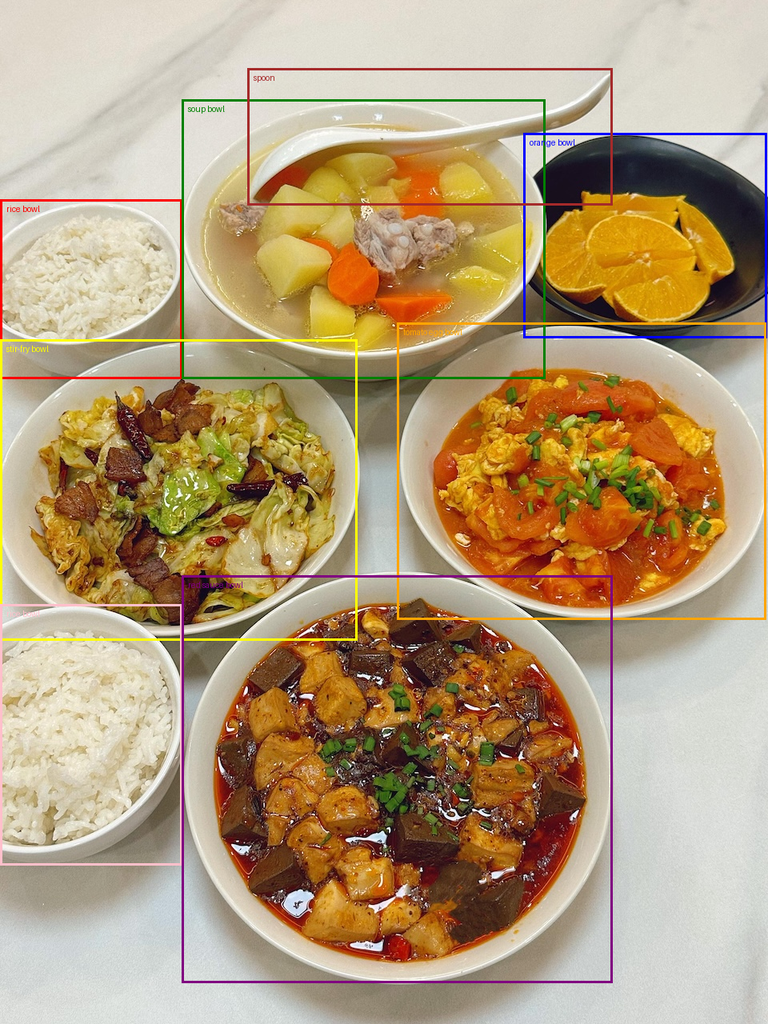

```python
# ---------- Sub-tarea 2: bounding boxes de sample-food.jpeg ----------
boxes_text = ask_vlm(
    "sample-food.jpeg",
    "Generate bounding boxes for the objects in the image. "
    'Return ONLY a JSON list where each item is {"bbox_2d": [x1, y1, x2, y2], "label": "<name>"}.'
)
print(boxes_text)


# Dibujar las cajas sobre la imagen (usa las funciones de la celda 35)
boxes = json.loads(parse_json(boxes_text))
image = Image.open("sample-food.jpeg").convert("RGB")
plot_bounding_boxes(image, boxes)
image   # muestra la imagen con las cajas
```

3. De la imágen boleta.png extraer número de boleta, artículos vendidos, unidades de cada artículo vendido, precio unitario, fecha de venta, y estructurar estos valores en un JSON (la salida del modelo debe contener una sección de texto con estructura JSON).

````python
def extract_json(text):
    """Extrae un JSON del texto: quita el razonamiento, el fence markdown y recorta al bloque {..} o [..]."""
    text = text.split("</think>")[-1]
    m = re.search(r"```(?:json)?\s*(.*?)```", text, re.DOTALL)
    if m:
        text = m.group(1)
    start = min([i for i in (text.find("{"), text.find("[")) if i != -1], default=-1)
    end = max(text.rfind("}"), text.rfind("]"))
    if start != -1 and end != -1:
        text = text[start:end + 1]
    return text.strip()
````

```
Tamaño: (350, 580)
```

[figure not shown]

```python
from PIL import Image

# Mostrar la boleta antes de extraer
boleta = Image.open("boleta.png").convert("RGB")
print("Tamaño:", boleta.size)
boleta   # muestra la imagen en el notebook
```

````python
receipt_text = ask_vlm(
    "boleta.png",
    "Extrae de esta boleta: numero_boleta, fecha_venta, y articulos "
    "(lista de objetos con {nombre, unidades, precio_unitario}). "
    "Responde ENVOLVIENDO el resultado en un bloque ```json ... ``` y nada más.",
    max_new_tokens=4096,
)
print("=== Texto crudo del modelo ===")
print(receipt_text)

try:
    receipt_json = json.loads(extract_json(receipt_text))
    print("\n=== JSON estructurado ===")
    print(json.dumps(receipt_json, indent=2, ensure_ascii=False))
except json.JSONDecodeError as e:
    print(f"\n⚠️ El modelo no devolvió JSON válido: {e}")
    print("Revisa el texto crudo de arriba y vuelve a ejecutar (o sube max_new_tokens).")
````

````
=== Texto crudo del modelo ===
Okay, let's tackle this problem. The user wants me to extract specific information from the provided electronic invoice (boleta) and format it into a JSON object with the keys: numero_boleta, fecha_venta, and articulos. Each of these needs to be a list of objects with nombre, unidades, and precio_un…

First, I need to parse the invoice. Let me look at the image description again. The top part has "R.U.T.: 77.315.257-K" and "BOLETA ELECTRONICA N° 120". So the numero_boleta should be 120. The date is "2020-09-28", which is the fecha_venta.

Next, the articulos section. The invoice lists items under "ARTICULO". Let's check each line:

1. COCA-COLA ORIGINAL 3: Cantidad (Cant) is 3.00, precio unitario (Precio Unit) is 2.100, total (Total) is 6.300.
2. FANTA 15: Cant is 1.00, Precio Unit is 1.800, Total is 1.800.

Wait, the user specified "articulos (lista de objetos con {nombre, unidades, precio_unitario})". But in the invoice, the "Cant" is the quantity, which is "unidades". So for each item, the nombre is the product name, unidades is the quantity (Cant), and precio_unitario is the price per unit (Precio U…

So for the first item: nombre is "COCA-COLA ORIGINAL 3", unidades is 3.00, precio_unitario is 2.100.

Second item: nombre "FANTA 15", unidades 1.00, precio_unitario 1.800.

Wait, but the user says "articulos (lista de objetos con {nombre, unidades, precio_unitario})". So the "unidades" here is the quantity, which is the Cant. So yes, that's correct.

Now, check if there are any other items. The invoice shows "TOTAL:" with 8.100, but that's the total amount, not part of the articulos list.

Also, the "Vendedor" is ADMIN, but that's not part of the required fields. The "Caja" is CAJA_150, but again, not needed.

So the three required fields are:

- numero_boleta: 120
- fecha_venta: 2020-09-28
- articulos: two items as per above.

Wait, the user says "articulos (lista de objetos con {nombre, unidades, precio_unitario})". So each object in the list should have those three fields. So the articulos list will have two entries.

Now, check the formatting. The user wants the JSON to be enclosed in ```json ... ``` and nothing else. So the structure should be:

{
  "numero_boleta": "120",
  "fecha_venta": "2020-09-28",
  "articulos": [
    {
      "nombre": "COCA-COLA ORIGINAL 3",
      "unidades": 3.00,
      "precio_unitario": 2.100
````

[output cut: 69 more lines]

```
  "numero_boleta": "120",
  "fecha_venta": "2020-09-28",
  "articulos": [
    {
      "nombre": "COCA-COLA ORIGINAL 3",
      "unidades": 3.0,
      "precio_unitario": 2.1
    },
    {
      "nombre": "FANTA 15",
      "unidades": 1.0,
      "precio_unitario": 1.8
    }
  ]
}
```